# Tratamiento de datos de Spotify

**Primero importamos las librerías necesarias**

**Instalamos seaborn para construir gráficas de barras**

```python
!pip install seaborn
```

```python
import pandas as pd
```

```python
import matplotlib.pyplot as plt
```

```python
import seaborn as sns
```

**Ahora definimos el archivo de donde leeremos los datos crudos**

*La linea encoding='latin-1' se usa para lograr que pandas lea caracteres especiales presentes en csv*

```python
df = pd.read_csv("Popular_Spotify_Songs (1).csv" ,encoding='latin-1')
```

```python
df_raw_data = df
```

**Ahora daremos un vistazo rápido a las dimensiones de nuestro DF**

```python
df.shape
```

```
(953, 24)
```

**Ahora sabemos que tenemos 953 filas y 24 columnas, desglocemos las columnas para empezar a limpiar**

```python
df.columns
```

```
Index(['track_name', 'artist(s)_name', 'artist_count', 'released_year',
       'released_month', 'released_day', 'in_spotify_playlists',
       'in_spotify_charts', 'streams', 'in_apple_playlists', 'in_apple_charts',
       'in_deezer_playlists', 'in_deezer_charts', 'in_shazam_charts', 'bpm',
       'key', 'mode', 'danceability_%', 'valence_%', 'energy_%',
       'acousticness_%', 'instrumentalness_%', 'liveness_%', 'speechiness_%'],
      dtype='object')
```

**Revisamos si tenemos datos faltantes en nuestras columnas**

```python
df.isna().sum().sort_values(ascending=False)
```

```
key                     95
in_shazam_charts        50
track_name               0
artist(s)_name           0
released_month           0
released_day             0
artist_count             0
released_year            0
in_spotify_charts        0
in_spotify_playlists     0
streams                  0
in_apple_playlists       0
in_deezer_playlists      0
in_apple_charts          0
in_deezer_charts         0
bpm                      0
mode                     0
danceability_%           0
valence_%                0
energy_%                 0
acousticness_%           0
instrumentalness_%       0
liveness_%               0
speechiness_%            0
dtype: int64
```

**En este caso, la limpieza será fácil, ya que solo dos columnas tienen datos vacíos. Para llenar esos datos usaremos:**

**"Key" se refiere a la clave musical en la que fue escrita la canción, la cambiaremos a do convencional como CC**

```python
df["key"] = df["key"].fillna("CC")
```

**Comprobamos el cambio realizado**

```python
df["key"].head(20)
```

```
0      B
1     C#
2      F
3      A
4      A
5     C#
6      F
7      F
8     C#
9      D
10    F#
11     F
12    CC
13     D
14    F#
15    G#
16     B
17    CC
18     B
19     G
Name: key, dtype: object
```

```python
df["in_shazam_charts"] = df["in_shazam_charts"].fillna("0")
```

```python
df["in_shazam_charts"].head(20)
```

```
0       826
1       382
2       949
3       548
4       425
5       946
6       418
7       194
8       953
9       339
10      251
11      168
12    1,021
13    1,281
14        0
15      187
16        0
17    1,173
18      187
19       29
Name: in_shazam_charts, dtype: object
```

**Generamos una vista general del DF para tomar ideas de distribución de los datos**

```python
df.head(20)
```

|  | track_name | artist(s)_name | artist_count | released_year | released_month | released_day | in_spotify_playlists | in_spotify_charts | streams | in_apple_playlists | ... | bpm | key | mode | danceability_% | valence_% | energy_% | acousticness_% | instrumentalness_% | liveness_% | speechiness_% |
| --- | --- | --- | --- | --- | --- | --- | --- | --- | --- | --- | --- | --- | --- | --- | --- | --- | --- | --- | --- | --- | --- |
| 0 | Seven (feat. Latto) (Explicit Ver.) | Latto, Jung Kook | 2 | 2023 | 7 | 14 | 553 | 147 | 141381703 | 43 | ... | 125 | B | Major | 80 | 89 | 83 | 31 | 0 | 8 | 4 |
| 1 | LALA | Myke Towers | 1 | 2023 | 3 | 23 | 1474 | 48 | 133716286 | 48 | ... | 92 | C# | Major | 71 | 61 | 74 | 7 | 0 | 10 | 4 |
| 2 | vampire | Olivia Rodrigo | 1 | 2023 | 6 | 30 | 1397 | 113 | 140003974 | 94 | ... | 138 | F | Major | 51 | 32 | 53 | 17 | 0 | 31 | 6 |
| 3 | Cruel Summer | Taylor Swift | 1 | 2019 | 8 | 23 | 7858 | 100 | 800840817 | 116 | ... | 170 | A | Major | 55 | 58 | 72 | 11 | 0 | 11 | 15 |
| 4 | WHERE SHE GOES | Bad Bunny | 1 | 2023 | 5 | 18 | 3133 | 50 | 303236322 | 84 | ... | 144 | A | Minor | 65 | 23 | 80 | 14 | 63 | 11 | 6 |
| 5 | Sprinter | Dave, Central Cee | 2 | 2023 | 6 | 1 | 2186 | 91 | 183706234 | 67 | ... | 141 | C# | Major | 92 | 66 | 58 | 19 | 0 | 8 | 24 |
| 6 | Ella Baila Sola | Eslabon Armado, Peso Pluma | 2 | 2023 | 3 | 16 | 3090 | 50 | 725980112 | 34 | ... | 148 | F | Minor | 67 | 83 | 76 | 48 | 0 | 8 | 3 |
| 7 | Columbia | Quevedo | 1 | 2023 | 7 | 7 | 714 | 43 | 58149378 | 25 | ... | 100 | F | Major | 67 | 26 | 71 | 37 | 0 | 11 | 4 |
| 8 | fukumean | Gunna | 1 | 2023 | 5 | 15 | 1096 | 83 | 95217315 | 60 | ... | 130 | C# | Minor | 85 | 22 | 62 | 12 | 0 | 28 | 9 |
| 9 | La Bebe - Remix | Peso Pluma, Yng Lvcas | 2 | 2023 | 3 | 17 | 2953 | 44 | 553634067 | 49 | ... | 170 | D | Minor | 81 | 56 | 48 | 21 | 0 | 8 | 33 |
| 10 | un x100to | Bad Bunny, Grupo Frontera | 2 | 2023 | 4 | 17 | 2876 | 40 | 505671438 | 41 | ... | 83 | F# | Minor | 57 | 56 | 72 | 23 | 0 | 27 | 5 |
| 11 | Super Shy | NewJeans | 1 | 2023 | 7 | 7 | 422 | 55 | 58255150 | 37 | ... | 150 | F | Minor | 78 | 52 | 82 | 18 | 0 | 15 | 7 |
| 12 | Flowers | Miley Cyrus | 1 | 2023 | 1 | 12 | 12211 | 115 | 1316855716 | 300 | ... | 118 | CC | Major | 71 | 65 | 68 | 6 | 0 | 3 | 7 |
| 13 | Daylight | David Kushner | 1 | 2023 | 4 | 14 | 3528 | 98 | 387570742 | 80 | ... | 130 | D | Minor | 51 | 32 | 43 | 83 | 0 | 9 | 3 |
| 14 | As It Was | Harry Styles | 1 | 2022 | 3 | 31 | 23575 | 130 | 2513188493 | 403 | ... | 174 | F# | Minor | 52 | 66 | 73 | 34 | 0 | 31 | 6 |
| 15 | Kill Bill | SZA | 1 | 2022 | 12 | 8 | 8109 | 77 | 1163093654 | 183 | ... | 89 | G# | Major | 64 | 43 | 73 | 5 | 17 | 16 | 4 |
| 16 | Cupid - Twin Ver. | Fifty Fifty | 1 | 2023 | 2 | 24 | 2942 | 77 | 496795686 | 91 | ... | 120 | B | Minor | 78 | 76 | 59 | 43 | 0 | 34 | 3 |
| 17 | What Was I Made For? [From The Motion Picture ... | Billie Eilish | 1 | 2023 | 7 | 13 | 873 | 104 | 30546883 | 80 | ... | 78 | CC | Major | 44 | 14 | 9 | 96 | 0 | 10 | 3 |
| 18 | Classy 101 | Feid, Young Miko | 2 | 2023 | 3 | 31 | 2610 | 40 | 335222234 | 43 | ... | 100 | B | Major | 86 | 67 | 66 | 14 | 0 | 12 | 16 |
| 19 | Like Crazy | Jimin | 1 | 2023 | 3 | 24 | 596 | 68 | 363369738 | 8 | ... | 120 | G | Major | 63 | 36 | 73 | 0 | 0 | 36 | 4 |

20 rows × 24 columns

**De acuerdo a la visualización previa podemos analisar y graficar los siguientes puntos**

**Comprobamos que tipo de valores en guardados**

```python
df.info()
```

```
<class 'pandas.core.frame.DataFrame'>
RangeIndex: 953 entries, 0 to 952
Data columns (total 24 columns):
 #   Column                Non-Null Count  Dtype
---  ------                --------------  -----
 0   track_name            953 non-null    object
 1   artist(s)_name        953 non-null    object
 2   artist_count          953 non-null    int64
 3   released_year         953 non-null    int64
 4   released_month        953 non-null    int64
 5   released_day          953 non-null    int64
 6   in_spotify_playlists  953 non-null    int64
 7   in_spotify_charts     953 non-null    int64
 8   streams               953 non-null    object
 9   in_apple_playlists    953 non-null    int64
```

[output cut: 16 more lines]

**Hacemos la conversion de valores string a valores númericos en Streams**

```python
df['streams'] = pd.to_numeric(df['streams'], errors='coerce')
```

```python
df.dropna(subset=['streams'], inplace=True)
```

```python
df['streams'] = df['streams'].astype('int64')
```

**Volvemos a comprobar los datos**

```python
df.info()
```

```
<class 'pandas.core.frame.DataFrame'>
Index: 952 entries, 0 to 952
Data columns (total 24 columns):
 #   Column                Non-Null Count  Dtype
---  ------                --------------  -----
 0   track_name            952 non-null    object
 1   artist(s)_name        952 non-null    object
 2   artist_count          952 non-null    int64
 3   released_year         952 non-null    int64
 4   released_month        952 non-null    int64
 5   released_day          952 non-null    int64
 6   in_spotify_playlists  952 non-null    int64
 7   in_spotify_charts     952 non-null    int64
 8   streams               952 non-null    int64
 9   in_apple_playlists    952 non-null    int64
```

[output cut: 16 more lines]

# Top 5 Artistas más escuchados en 2023

**Filtramos todos los datos del 2023**

```python
df_2023 = df[df['released_year'] == 2023].copy()
```

**Agrupamos y sumamos los 5 artistas de la DF**

```python
top_artists_2023 = df_2023.groupby('artist(s)_name')['streams'].sum().sort_values(ascending=False).head(5)
```

**Construimos la grafica**

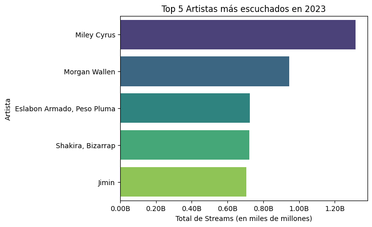

```python
plt.figure
sns.barplot(x=top_artists_2023.values, y=top_artists_2023.index, palette='viridis')
plt.title('Top 5 Artistas más escuchados en 2023')
plt.xlabel('Total de Streams (en miles de millones)')
plt.ylabel('Artista')
plt.gca().xaxis.set_major_formatter(plt.FuncFormatter(lambda x, pos: f'{x / 1e9:.2f}B'))
plt.show()
```

# Crecimiento de The Weeknd (últimos 10 años)

**Establecemos el año de referencia**

```python
current_year = 2023
```

**Encontramos el artista con más streams en total**

```python
top_artist_overall = df.groupby('artist(s)_name')['streams'].sum().idxmax()
```

**Filtrar los datos solo para este artista**

```python
artist_df = df[df['artist(s)_name'] == top_artist_overall]
recent_artist_df = artist_df[artist_df['released_year'] >= (current_year - 10)]
```

**Agrupamos por año y sumamos los streams**

```python
streams_growth = recent_artist_df.groupby('released_year')['streams'].sum()
```

**Construimos la grafica**

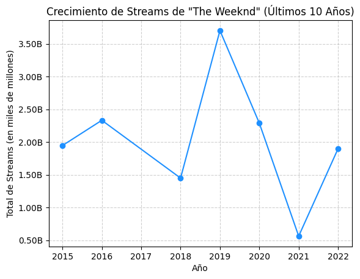

```python
plt.figure
plt.plot(streams_growth.index, streams_growth.values, marker='o', linestyle='-', color='dodgerblue')
plt.title(f'Crecimiento de Streams de "{top_artist_overall}" (Últimos 10 Años)')
plt.xlabel('Año',)
plt.ylabel('Total de Streams (en miles de millones)')
plt.grid(True, linestyle='--', alpha=0.6)
plt.gca().yaxis.set_major_formatter(plt.FuncFormatter(lambda x, pos: f'{x / 1e9:.2f}B'))
plt.show()
```

# Tonalidad musical más exitosa en los últimos 5 años

**Filtramos datos de los últimos 5 años**

```python
recent_df = df[df['released_year'] >= 2019]
```

**Agrupamos por tonalidad y sumamos los streams**

```python
successful_keys = recent_df.groupby('key')['streams'].sum().sort_values(ascending=False)
```

**Construimos la grafica**

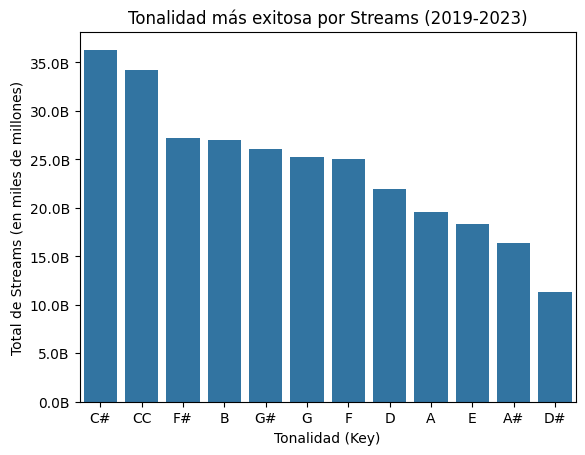

```python
plt.figure
sns.barplot(x=successful_keys.index, y=successful_keys.values)
plt.title('Tonalidad más exitosa por Streams (2019-2023)')
plt.xlabel('Tonalidad (Key)')
plt.ylabel('Total de Streams (en miles de millones)')
plt.gca().yaxis.set_major_formatter(plt.FuncFormatter(lambda x, pos: f'{x / 1e9:.1f}B'))
plt.show()
```

# Top 5 Artistas menos escuchados (2023)

**Volvemos a filtrar datos de 2023**

```python
df_2023 = df[df['released_year'] == 2023].copy()
```

```python
artist_streams_2023 = df_2023.groupby('artist(s)_name')['streams'].sum()
```

**Ordenamos de menor a mayor y tomamos los 5 primeros**

```python
least_listened_2023 = artist_streams_2023.sort_values(ascending=True).head(5)
```

**Construimos la grafica**

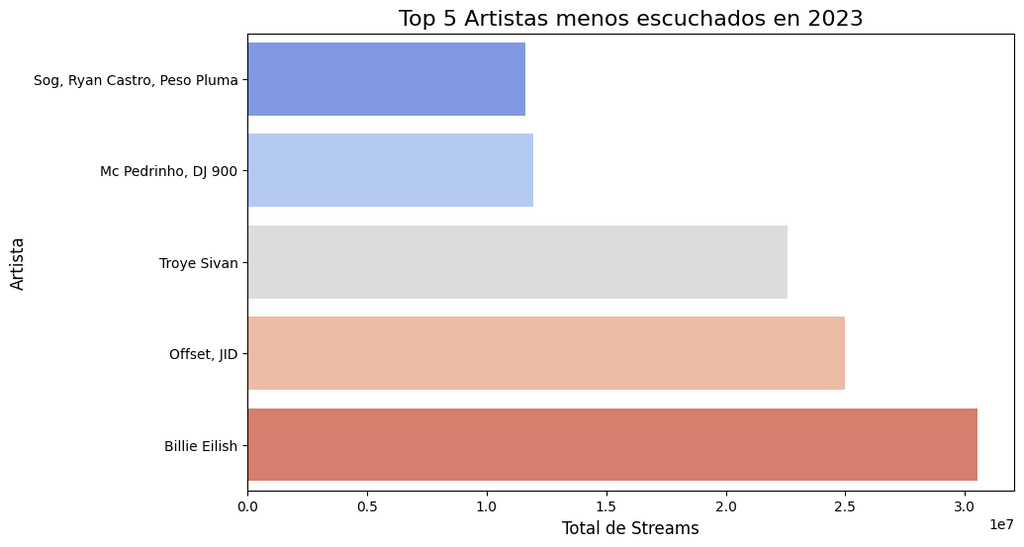

```python
plt.figure(figsize=(10, 6))
sns.barplot(x=least_listened_2023.values, y=least_listened_2023.index, palette='coolwarm')
plt.title('Top 5 Artistas menos escuchados en 2023', fontsize=16)
plt.xlabel('Total de Streams', fontsize=12)
plt.ylabel('Artista', fontsize=12)
plt.show()
```

# Número de canciones lanzadas por mes

**Contamos las canciones que se lanzaron en cada mes y ordenamos por mes**

```python
songs_per_month = df['released_month'].value_counts().sort_index()
```

**En un diccionario mapeamos los números de los meses a sus nombres**

```python
month_map = {1: 'Enero', 2: 'Febrero', 3: 'Marzo', 4: 'Abril', 5: 'Mayo', 6: 'Junio',
             7: 'Julio', 8: 'Agosto', 9: 'Septiembre', 10: 'Octubre', 11: 'Noviembre', 12: 'Diciembre'}
songs_per_month.index = songs_per_month.index.map(month_map)
```

**Creamos la grafica**

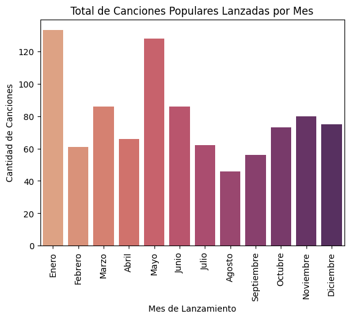

```python
plt.figure
sns.barplot(x=songs_per_month.index, y=songs_per_month.values, palette='flare')
plt.title('Total de Canciones Populares Lanzadas por Mes')
plt.xlabel('Mes de Lanzamiento')
plt.ylabel('Cantidad de Canciones')
plt.xticks(rotation=90)
plt.show()
```